# Linking avian pollination and frugivory to *Cactaceae* seed dispersal and successful facilitation.

Malory Owen and Chris Lortie

November 27th, 2018

# Timeline

Table 1: A proposed timeline of the three chapters

| Chapter | Title | Goal | Timeline |
| --- | --- | --- | --- |
| 1 | Fruiting metrics in Cactaceae- A meta-analysis | Identify and isolate the combined results of relevant studies in Cactaceae in regards to fruiting patterns. | Derived data extracted by December 2018. Paper written by January 2019. |
| 2 | Strength of birds as pollinators and seed dispersers in Cactaceae | Connect bird interactions with flowering and fruiting in cacti of different endangerment status. | Flowering field season January-February April-May 2019. Fruiting field season August 2019. Paper written by January 2020. |
| 3 | Avian pollination and seed dispersal influence on seed shadow of Cactaceae obligatory facilitatees | Determine the role of birds as pollinators and seed dispersers for Saguaro ssp. | Flowering field season April-May 2020. Fruiting field season August 2020. Paper written by December 2020. |

# Introduction

Desert ecosystems are threatened by a variety of circumstances. Anthropogenic actions like climate change and habitat fragmentation are perpetuating arid ecosystem degradation. Specifically, climate change increases severe precipitation changes such as droughts and flooding (Nielsen and Ball 2015; Pfahl, O’Gorman, and Fischer 2017; Singh et al. 2013; Smith 2011), and human development like roads, solar panels, and land use change fragments and destroys habitats (Gutzwiller and Barrow 2003; Hernandez et al. 2014; Rodriguez-Estrella 2007). In the American Southwest, arid ecosystems are home to 350 endangered/threatened plants and animals (State of California Natural Resource Agency 2018; State of California Natural Resources Agency 2018), provide ecosystem services to humans (Taylor et al. 2017), and have cultural significance to indigenous peoples. In order to restore the region and mitigate the effects of climate change and human development, we must understand the connections that support and sustain biodiversity in deserts.

Positive interactions are any associative action between interspecifics where one species benefits performance or fitness of another in some capacity (M. D. M. Bertness and Callaway 1994). Positive interactions are shown to be strong determinants of the structure of ecosystems, thereby showing the interconnected and non-random way communities are formed (R. M. Callaway 1997; Gelmi-Candusso, Heymann, and Heer 2017). In a similar, but narrower sense, facilitation is the process by which a foundational species perpetuates the success of many other individuals within an ecosystem–particularly in years of high stress (F. T. Maestre et al. 2009). This concept suggests that facilitation among plants and animals by foundational species is a driving forces behind an ecosystem’s development (Angelini et al. 2011; Almeida and Mikich 2018). Additionally, these interactions are evolutionarily beneficial to parties due to the mutualistic nature of the benefits the interacting individuals may receive both within and between species, even when costs are accounted for (Barker et al. 2017; Bronstein 2009; Bronstein 2001). In arid ecosystems, positive interactions can provide water and shade from excessive solar radiation for other plants and animals (Flores-Torres and Galindo-Escamilla 2017; Miranda-Jacome, Montaña, and Fornoni 2013), or to a lesser extent, prevent physical damage from herbivory, wind, and freezing temperatures (Gomez-Aparicio et al. 2008; Parker 1989; Tewksbury and Lloyd 2001; P. S. Nobel 1980). Benefactor plants provide these amenities to seedlings, improve recruitment, germination, and growth in juvenile plants (Franco and Nobel 2009). This makes benefactor plants important facilitators for many species. Some of these protege plants are even obligated to be deposited under the canopy of a benefactor plant to germinate at all (Taly D. Drezner and Garrity 2003; Taly Dawn Drezner 2010). Therefore, the benefactor plant is a limiting factor in the growth of many plant species.

However, a seed must arrive under the canopy of a benefactor plant in order to receive the benefits of associating with a benefactor. Because plants are sessile lifeforms, the movement of seeds must rely of some abiotic or biotic vector of transportation (Nathan and Muller-landau 2000). Seed rain is the placement of of a seed after being deposited either through endozoochory, exozoochory, wind dispersal, or mechanical dispersal, whereas seed shadow refers to the placement of daughter seeds relative to the mother plant (Willson 1993). There is ample research in regards to the successful recruitment and germination of seed rain based on the benefactor plant as well as the effect of the endozoochorous disperser’s gut on germination rate and success (Verdu and Traveset 2004; A Traveset, Riera, and Mas 2001; A. Traveset and Verdú 2002). This research provides the base work to enhance our knowledge on the relative importance of dispersers, particularly in arid ecosystems and to the end of deposition at facilitating benefactor plants. These interactions are examples of non-trophic, mechanistic pathways that directly determine the biodiversity of birds and cacti, and indirectly influences the biodiversity of other benefactor species, as cacti are keystone species in arid ecosystems (Lortie, Filazzola, and Sotomayor 2016).

There are two instances of positive interactions that perpetuate seed dispersal: pollination and frugivory. This connection of two mutualistic events through a single taxonomic group is known as double mutualism, and is a rare event but present in birds (Kelly et al. 2004; Ladley and Kelly 1996). Double mutualism is most common in harsh ecosystems with relatively low biodiversity, such as arid deserts (Garcia, Espadaler, and Olesen 2012; Gomes, Quirino, and Araujo 2014). We suggest that double mutualism of cacti by pollinating/frugivorous birds may be a key factor in cactus reproduction, and eventual successful facilitation. Mechanistically, in order to be dispersed via bird frugivory, a cactus must have some characteristic which drives that frugivory. As allocation theory suggests, cacti have evolved to allocate energy and resources to anatomical traits that best increase their relative fitness (Obeso 2004). Perhaps these traits that are attractive to frugivorous birds also improve fitness beyond just ability to be dispersed. For example, fruit size/number and seed size/number are reproductive organ characteristics which may determine both frugivory, and by extension, fitness in plants. Fruit and frugivory are not the only ways birds increase fitness of cacti. Fruiting is dependent on pollination, a service that birds, particularly hummingbirds, can provide. Foragers (like pollinators) will sacrifice energy while foraging until a patch’s resource availability is equal to the average resource availability of the entire habitat, or until the energy expended foraging outweighs the energy gained. This resource density value is known as the Giving-up Density (GUD), and is based on the Marginal value theorem (MVT) which is a model that predicts foraging behavior when resources exist in patches (Charnov 1976). This principle governs pollination visitation, a metric for pollination interaction strength. Height of inflorescence and showiness of inflorescence display are contributing factors to hummingbird pollinator visitation, as higher flowers are more likely to be seen by flying hummingbirds (Wolf and Hainsworth 1990; Mitchell 1994), and more flowers will draw more hummingbirds. If larger cacti have more flowers, we may expect more hummingbird pollinator visits, and therefore produce more fruit, thereby increasing relative fitness for cacti.

Bird-cacti interactions are likely driving forces behind the infrastructure of desert ecosystems, but more research on plant-animal interactions is needed. Members of the Cactaceae family in the *Opuntia* and *Clyndropuntia* genuses, which are both benefactors and proteges, may rely heavily on positive bird interactions at the flowering and fruiting stage to reproduce successfully. In these studies, we will identify the pollinating and dispersing strength of birds for different species and characteristics of cacti, and increase understanding of interactions at the community level’s role in determining an ecosystem’s biotic structure.

## Study Site

**Mojave Desert: Sweeney Granite Mountains Desert Reseach Center** The Sweeney Granite Mountains Desert Research Center in the Mojave Desert (34.8056°N, 115.6639°W) is located in San Bernadino Country. It boasts a high species richness of 504 vascular plant, 156 birds, 42 mammals, and 2 amphibians. The site has an average of 23 cm of precipitation annually. The July maximum and minimum mean temperature of 33 degrees C and 20 degrees C, respectively, and a December maximum and minimum mean temperature of 8 degrees C and -1 degrees C, respectively. The elevation range is 1,128 to 2,071 meters. It is home to two species of interest, Buckhorn Cholla (*Cylindroputia acanthocarpa*) and Beavertail Prickly Pear (*Opuntia basilaris*).

# Study Species

**Opuntia basilaris**, also known as Beavertail, is a frequently occurring species of the family Cactaceae. Found at 800-1900 meters above sea level in gravelly bajadas, washes, and pinyon-juniper woodland (a common habitat in the Granite Mountains) , this species is more easily accessible than some other *Opuntia* species (Andre 2006). Like other members of the *Opuntia* genus, this species is distinct for its “paddle” shaped leaves and bright pink flowers. It is listed as secure by The Nature Conservancy.

**Cylindropuntia acanthocarpa**, or Buckhorn Cholla, is another member of the Cactaceae family found in the Mojave desert and Granite Mountains. Found commonly in gravelly bajadas at 900-1500 meters above sea-level, it has similar accessibility as *O. basilaris* Andre (2006)]. With an appearance more like a small, spiky tree and large red flowers, the genus *Cyclindropuntia* was recently split from the *Opuntia* genus (P. S. Nobel 2002).

**Carnegiea gigantea**, commonly known as Saguaro, is a columnar cactus found in the Sonoran Desert. A distinctive species, it’s large, white, waxy flowers bloom at the apex of the arms or spire of the plant. While they can live between 150-200 years, they are obligated to be facilitated by benefactor plants (Taly Dawn Drezner 2014). They also require wet environments for germination, a limiting factor in the American Southwest (Turner et al. 1966).

# Chapter 1: Fruiting metrics in Cactaceae: A meta-analysis

## Purpose

This meta-analysis will provide a comprehensive analysis of studies related to fruit and seeds of plants within the Cactaceae family including allocation theory.

## Research Questions

1. Are fruit and seed size/production related?
2. Are size and branching related to age, and do they influence reproductive success independent of age?
3. Are cacti species nearer on the phylogenetic tree allocating energy in similar ways?

## Strategy of the systematic review

I will perform a systematic review of fruiting cacti and their size, isolating the relevant studies as data points for a meta-analysis through a series of filtering mechanisms (Fig 1). The following search terms were used in Web of Science: “cact”, “seed”, “fruit”, “allocat”, and “size”. All papers must have been published in the past 5 years, be ecological in discipline, and report a regression or correlation coefficient.

## Progress to date

At this time, 302 papers have been compiled after removing duplicates. Next steps are identifying papers as fitting requirements prefaced above, and then compiling the data points (regression and correlation coefficients). Finally, we will summarize the pooled results of the relevant papers.

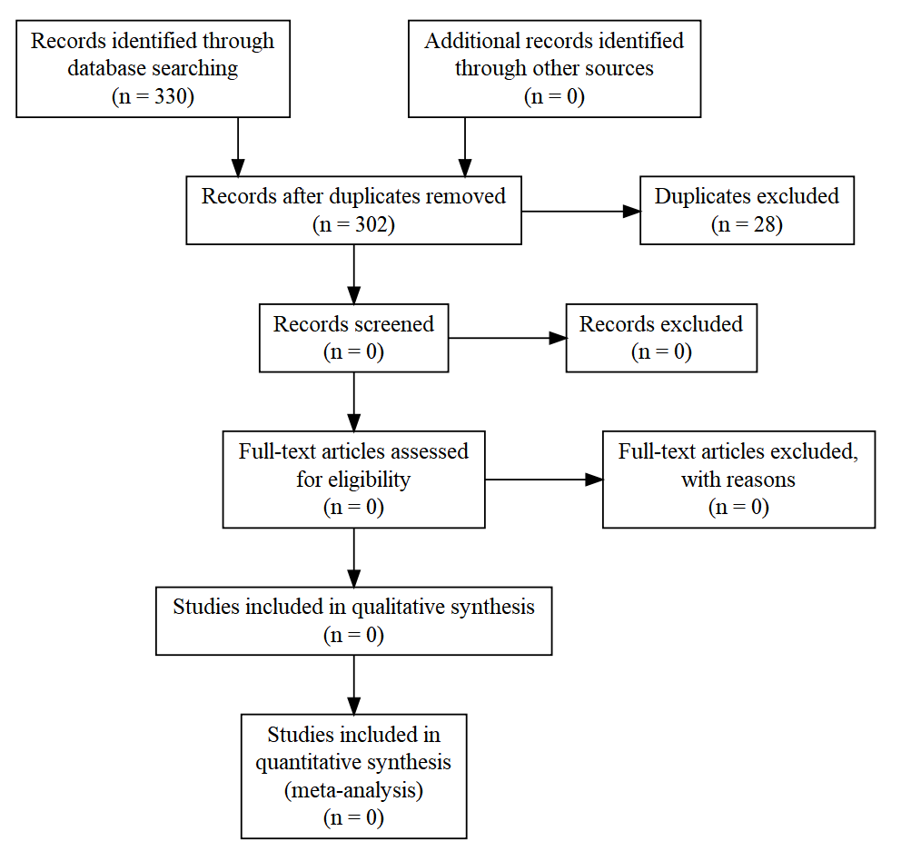

Fig 1: A PRIMSA statement identifying the workflow completed to date for the systematic review of papers to be included in the meta-analysis (Moher et al. 2009).

# Chapter 2: Strength of birds as pollinators and seed dispersers in Cactaceae

## Research Questions

1. How strong are bird-cacti interactions based on different cactus characteristics?
2. Is there a relationship between seed size, seed abundance, fruit size, fruit/flower abundance, and cactus size?

## Hypotheses and Predictions

Hypothesis: Birds and cacti are linked through positive interactions in desert ecosystems, with plant size being a determining factor of interaction strength. Predictions a. Bird visitation rates for pollination and frugivory are positively related to cactus characteristics. b. The bird-cacti relationship is species specific (both for bird and cacti species).

## Factors

- **Percentage of flower/fruit on cactus**: 0%, 25%, 50%, 75%, 100%
- *0% fruit on cactus is the negative control, 100% fruit on cactus is positive control for fruit abundance*
- **Species of cactus**: *Opuntia basilaris* or *Cylindropuntia anthrocarpa*
- **Size of cactus individual**: Large, medium, small as defined by equally-sized bins after the preliminary survey

## Responses

- Bird visitation rate
- Bird species richness and diversity per cactus
- Proportion of frugivous birds present relative to non frugivorous birds
- Mass of individual fruits/seeds
- Number of seeds per fruit
- Number of fruits/flowers per cactus
- Number of cactus branches

## Methods and Experimental Design

### Site specific metrics

A preliminary survey of 100 individuals for each study species will be done at the start of the growing season in 2019. The individuals will be selected using a random number generator corresponding to individuals on transects. The size of cacti will be measured including height, dbh, and total number of branches. *Opuntia basilaris* and *Cylindropuntia anthrocarpa* are found in the SGMDRC. On each transect, the total density of all cacti species will also be recorded using a distance to nearest neighbor point measure in a line transect (Krebs 2014). Transects are 100m long, starting from a randomly generated point, with a point of measurement being every 5m. There will be 6 replications of transects. Upon further collaboration with GIS and remote sensing experts, we will use satellite imagery or ground-based LiDAR to perform site-wide diversity/density measurements. The preliminary week is to ensure my sample size and time frame are reasonable, should any components of the experimental design require revision.

In addition to surveying cactus density and diversity, we will also conduct density and diversity surveys of birds at the site. While walking 1km transects, we will record the presence and transect meter for all birds seen or heard, and identify them to the best of our ability. Doing this once every 7 days will give us a better idea of the total bird diversity/density of the site.

### Flowering Experiment

Pending the exploratory week, we will return in April/May during the flowering season to observe pollinating birds interactions with 300 cactus individuals (10 replications per characteristic combination). The cacti will have different levels of manipulated “showiness” (0%, 25%, 50%, 75%, 100% percent of flowers) of the 3 size classes and 2 species. We will snip X% of buds off the cactus, but also record the number of blooming flowers on each individual when performing observations, as not all flowers of a cactus bloom concurrently.

While the flowering season for our study cacti is in May, the cactus individual itself only blooms for 1-2 days throughout the season. Additionally, we are most interested in hummingbirds as pollinators, which are nearly impossible to document on camera traps and difficult to identify by eye in the field (especially female/juveniles). Because of these constraints, we will primarily rely on focal observations aided by a 200-500mm digital camera. We will do 1-hour observations in mornings and evenings at each combination of variables 4 times (120 hours of observations). During this time, we will also be equipped with audio recorders with parabolic shields to make recordings of bird calls *ad libitum*.

### Fruiting Experiment

We will place a camera trap at an individual sample cactus for all combinations of variables >5m away from the cactus (30 cameras). We will leave this camera to record movement for 5 days taking still images. After 5 days, we will randomly choose a new cactus/open site for each treatment combination to place camera traps at. We will replicate this process 5 times, over 25 days. Because camera traps may be unreliable recorders of bird abundance, we will also use audio recordings to measure bird presence. We will record during our focal observations (see below) *ad libitum* during both the cactus and open observations. Sound recorders have been shown to be as reliable a measurement of bird presence compared to walking point transects, and are more time and cost effective (Darras et al. 2018). To identify bird calls, we will classify the calls by ear, and then use a audio software program, like Sound Analysis Pro 2011 to identify the many hours of audio data (L. A. Grieves, Logue, and Quinn 2014; Leanne A. Grieves, Logue, and Quinn 2015).

In addition to passive monitoring, we will also perform focal observations, equipped with 200-500mm digital cameras. We will be at least 10 meters from the cactus, so as not to impact bird abundance. These focal observations will last for 1 hour in mornings or evenings, and be performed 4 times at each combination of treatments (120 total hours of focal observation). We will record each bird individual’s species and behavior (using an ethogram). Should there be more than one individual present, we will record the visiting species, but continue behavior observation for the first arrival birds (for up to 10 minutes, although this time limit is unlikely to be surpassed considering bird movement). Once the focal bird has left the cactus of interest, we will note the location it arrived at after leaving the cactus of interest.

## Paired Flower and Fruit Observations

Because the manipulated flowering and fruiting cacti will not be paired, we will also perform a paired observational study. To link flowering number to fruiting number, we will find 20 individuals of each species (40 cacti total) in flowering season, and count the number of flowers/buds, determine the branching pattern, and measure their volume (x, y, z axis). We will also measure the sucrose content of the nectar for each plant using a radiometer, as sucrose is the nutritional source in nectar for hummingbirds (Martinez Del Rio 1990). These cacti will be geographically logged, and revisited in the fruiting season. In August, we will similarly collect and count the number of fruit. These data will allow us to compare flowering patterns with fruiting patterns in paired individuals across species.

# Chapter 3: Avian pollination and seed dispersal influence on seed shadow of Cactaceae obligate protege plants

## Purpose

This chapter will test the importance of birds as seed dispersers for cacti which are, at different life stages, beneficiaries and benefactors of facilitating plants and animals respectively. Specifically, the Saguaro cactus. This chapter has the same methods as Chapter 2.

## Research Questions

1. Are pollinating/frugivorous birds stronger interactors for larger cacti?
2. Is cactus size an indicator for fruit mass/abundance? For flower abundance?
3. Is there a relationship between seed size, seed abundance, fruit size, fruit abundance, and cactus size?

## Hypotheses

Positive interactions between birds and cacti are the limiting factor in cacti distribution to the canopy of a benefactor shrub, with plant size and allocation being a determining factor in interaction strength. Predictions a. Bird visitation rates for pollination and frugivory are positively related to cacti size and floral display. b. The bird-cacti relationship is species specific (both for bird and cacti species).

## Factors

- **Percentage of fruit on cactus**: 0%, 25%, 50%, 75%, 100%
- *0% fruit on cactus is the negative control, 100% fruit on cactus is positive control for fruit abundance*
- **Size of cactus individual**: Large, medium, small

## Response

- Mass of individual fruits/seeds
- Number of flowers/fruits per cactus
- Number of seeds per fruit
- Bird visitation rate
- Species richness and diversity per cactus
- Proportion of frugivous birds present relative to non frugivorous birds

## Methods

All methods in regards to density, flowering, fruiting, and seed manipulations/measurements will be the same as in Chapter 2. Additionally, the methods to monitor bird species will also remain the same (camera trapping, audio recording, focal observations, and walking surveys).

# Future Work

This study opens up at least two side projects, potentially to be conducted by an undergraduate research assistant. One would be linking bird frugivory to seed shadow using seed trays placed under different mesohabitats. For example, the trays could be placed under benefactor shrubs, cacti, and open spaces. This would help complete the circle of my thesis chapters. Additionally, by collecting fruit and seed samples, a collaborator could identify nutrition offered to bird species by facilitating cactus species. This would offer a better understanding of the importance of these cactus species to the community structure.

# References

Almeida, Adriana de, and Sandra Bos Mikich. 2018. “Combining plant–frugivore networks for describing the structure of neotropical communities.” *Oikos* 127 (2): 184–97. doi:10.1111/oik.04774.

Andre, J.M. 2006. “Vascular flora of the Granite Mountains, San Bernardino County: An annotated checklist.” *Crossosoma* 32 (2): 38–74.

Angelini, Christine, Andrew H. Altieri, Brian R. Silliman, and Mark D. Bertness. 2011. “Interactions among Foundation Species and Their Consequences for Community Organization, Biodiversity, and Conservation.” *BioScience* 61 (10): 782–89. doi:10.1525/bio.2011.61.10.8.

Barker, Jessica L., Judith L. Bronstein, Maren L. Friesen, Emily I. Jones, H. Kern Reeve, Andrew G. Zink, and Megan E. Frederickson. 2017. “Synthesizing perspectives on the evolution of cooperation within and between species.” *Evolution* 71 (4): 814–25. doi:10.1111/evo.13174.

Bertness, Mark D. M.D., and Ragan Callaway. 1994. “Positive interactions in communities.” *Tree* 9 (5): 191–93. doi:10.1016/0169-5347(94)90088-4.

Bronstein, Judith L. 2001. “The Costs of Mutualism.” *American Zoology* 41: 825–39.

———. 2009. “The evolution of facilitation and mutualism.” *Journal of Ecology* 97 (6): 1160–70. doi:10.1111/j.1365-2745.2009.01566.x.

Callaway, Ragan M. 1997. “Positive interactions in plant communities and the individualistic-continuum concept.” *Oecologia* 112: 143–49.

Charnov, Eric. 1976. “Optimal foraging : The marginal value theorem.” *Theoretical Population Biology* 9 (2): 129–36.

Darras, Kevin, Péter Batáry, Brett Furnas, Antonio Celis-Murillo, Steven L. Van Wilgenburg, Yeni A. Mulyani, and Teja Tscharntke. 2018. “Comparing the sampling performance of sound recorders versus point counts in bird surveys: A meta-analysis.” *Journal of Applied Ecology*, no. June: 2575–86. doi:10.1111/1365-2664.13229.

Drezner, Taly D., and Colleen M. Garrity. 2003. “Saguaro distribution under nurse plants in arizona’s sonoran desert: Directional and microclimate influences.” *Professional Geographer* 55 (4): 505–12. doi:10.1111/0033-0124.5504008.

Drezner, Taly Dawn. 2010. “Nurse tree canopy shape, the subcanopy distribution of cacti, and facilitation in the Sonoran Desert.” *The Journal of the Torrey Botanical Society* 137 (2–3): 277–86. doi:10.3159/09-RA-069R1.1.

———. 2014. “The keystone saguaro (Carnegiea gigantea, Cactaceae): A review of its ecology, associations, reproduction, limits, and demographics.” *Plant Ecology* 215 (6): 581–95. doi:10.1007/s11258-014-0326-y.

Flores-Torres, Arnoldo, and Andrea Galindo-Escamilla. 2017. “Pollination biology of Agave horrida (Agavaceae) in the Chichinautzin mountain range, in Central Mexico".” *Botanical Sciences* 95 (3): 423–31. doi:10.17129/botsci.1022.

Franco, Author A C, and P S Nobel. 2009. “Effect of Nurse Plants on the Microhabitat and Growth of Cacti Published by : British Ecological Society Stable URL : http://www.jstor.org/stable/2260991” 77 (3): 870–86.

Garcia, Maria B., Xavier Espadaler, and Jens M. Olesen. 2012. “Extreme Reproduction and Survival of a True Cliffhanger : The Endangered Plant Borderea chouardii.” *PLOS One* 7 (9): 1–7. doi:10.1371/journal.pone.0044657.

Gelmi-Candusso, Tiziana A., Eckhard W. Heymann, and Katrin Heer. 2017. “Effects of zoochory on the spatial genetic structure of plant populations.” *Molecular Ecology* 26 (21): 5896–5910. doi:10.1111/mec.14351.

Gomes, VGN, ZGM Quirino, and HFP Araujo. 2014. “Frugivory and seed dispersal by birds in Cereus jamacaru DC. ssp. jamacaru (Cactaceae) in the Caatinga of Northeastern Brazil.” *Brazilian Journal of Biology* 74 (1): 32–40. doi:10.1590/1519-6984.15312.

Gomez-Aparicio, Lorena, Regino Zamora, Jorge Castro, and Jose A. Hódar. 2008. “Facilitation of tree saplings by nurse plants: Microhabitat amelioration or protection against herbivores?” *Journal of Vegetation Science* 19 (2): 161–72. doi:10.3170/2008-8-18347.

Grieves, L. A., D. M. Logue, and J. S. Quinn. 2014. “Joint-nesting smooth-billed anis, Crotophaga ani, use a functionally referential alarm call system.” *Animal Behaviour* 89. Elsevier Ltd: 215–21. doi:10.1016/j.anbehav.2014.01.008.

Grieves, Leanne A., David M. Logue, and James S. Quinn. 2015. “Vocal repertoire of cooperatively breeding Smooth-billed Anis.” *Journal of Field Ornithology* 86 (2): 130–43. doi:10.1111/jofo.12096.

Gutzwiller, Kevin J., and Wylie C. Barrow. 2003. “Influences of roads and development on bird communities in protected Chihuahuan Desert landscapes.” *Biological Conservation* 113 (2): 225–37. doi:10.1016/S0006-3207(02)00361-0.

Hernandez, R. R., S. B. Easter, M. L. Murphy-Mariscal, F. T. Maestre, M. Tavassoli, E. B. Allen, C. W. Barrows, et al. 2014. “Environmental impacts of utility-scale solar energy.” *Renewable and Sustainable Energy Reviews* 29. Elsevier: 766–79. doi:10.1016/j.rser.2013.08.041.

Kelly, Dave, Jenny J Ladley, Alastair W Robertson, and Jenny J Ladley. 2004. “Is dispersal easier than pollination ? Two tests in New Zealand Loranthaceae.” *New Zealand Journal of Botany* 42: 89–103. doi:10.1080/0028825X.2004.9512892.

Krebs, Charles J. 2014. *Ecological Methodology*. 2nd ed. Addison Wesley Longman, Inc. doi:10.1109/NANO.2014.6968124.

Ladley, Jenny J, and Dave Kelly. 1996. “DISPERSAL , GERMINATION AND SURVIVAL OF NEW ZEALAND MISTLETOES ( LORANTHACEAE ): DEPENDENCE.” *New Zealand Journal of Ecology* 20 (1): 69–79.

Lortie, Christopher J., Alessandro Filazzola, and Diego A. Sotomayor. 2016. “Functional assessment of animal interactions with shrub-facilitation complexes: A formal synthesis and conceptual framework.” *Functional Ecology* 30 (1): 41–51. doi:10.1111/1365-2435.12530.

Maestre, Fernando T., Ragan M. Callaway, Fernando Valladares, and Christopher J. Lortie. 2009. “Refining the stress-gradient hypothesis for competition and facilitation in plant communities.” *Journal of Ecology* 97 (2): 199–205. doi:10.1111/j.1365-2745.2008.01476.x.

Martinez Del Rio, Carlos. 1990. “Sugar Preferences in Hummingbirds : The Influence of Subtle Chemical Differences on Food Choice.” *The Condor* 92 (4): 1022–30.

Miranda-Jacome, Antonio, Carlos Montaña, and Juan Fornoni. 2013. “Sun/shade conditions affect recruitment and local adaptation of a columnar cactus in dry forests.” *Annals of Botany* 111 (2): 293–303. doi:10.1093/aob/mcs255.

Mitchell, Randall J. 1994. “Effects of Floral Traits , Pollinator Visitation , and Plant Size on Ipomopsis aggregata Fruit Production” 143 (5): 870–89.

Moher, David, Alessandro Liberati, Jennifer Tetzlaff, Douglas G Altman, and the PRISMA Group. 2009. “Preferred Reporting Items for Systematic Reviews and Meta-Analyses :” *Annals of Internal Medicine* 151 (4): 264–69. doi:10.1371/journal.pmed1000097.

Nathan, R., and H. C. Muller-landau. 2000. “Spatial patterns of seed dispersal, their determinants and consequences for recruitment.” *Trends in Ecology & Evolution* 15 (7): 278–85. doi:10.1016/S0169-5347(00)01874-7.

Nielsen, Uffe N., and Becky A. Ball. 2015. “Impacts of altered precipitation regimes on soil communities and biogeochemistry in arid and semi-arid ecosystems.” *Global Change Biology* 21 (4): 1407–21. doi:10.1111/gcb.12789.

Nobel, Park S. 1980. “Morphology , Nurse Plants , and Minimum Apical Temperatures for Young Carnegiea gigantea Author ( s ): Park S . Nobel Published by : The University of Chicago Press Stable URL : http://www.jstor.org/stable/2474851 Accessed : 16-05-2016 19 : 34 UTC Your us.” *Botanical Gazette* 141 (2): 188–91.

———. 2002. *Cacti Biology and Uses*. 1.

Obeso, José Ramón. 2004. “A hierarchical perspective in allocation to reproduction from whole plant to fruit and seed level.” *Perspectives in Plant Ecology, Evolution and Systematics* 6 (4): 217–25. doi:10.1078/1433-8319-00080.

Parker, Kathleen C. 1989. “Nurse plant retationships of columnar cacti in arizona.” *Physical Geography* 10 (4): 322–35. doi:10.1080/02723646.1989.10642386.

Pfahl, S., P. A. O’Gorman, and E. M. Fischer. 2017. “Understanding the regional pattern of projected future changes in extreme precipitation.” *Nature Climate Change* 7 (6): 423–27. doi:10.1038/nclimate3287.

Rodriguez-Estrella, Ricardo. 2007. “Land use changes affect distributional patterns of desert birds in the Baja California peninsula, Mexico.” *Diversity and Distributions* 13 (6): 877–89. doi:10.1111/j.1472-4642.2007.00387.x.

Singh, Deepti, Michael Tsiang, Bala Rajaratnam, and Noah S. Diffenbaugh. 2013. “Precipitation extremes over the continental United States in a transient, high-resolution, ensemble climate model experiment.” *Journal of Geophysical Research Atmospheres* 118 (13): 7063–86. doi:10.1002/jgrd.50543.

Smith, Melinda D. 2011. “The ecological role of climate extremes: Current understanding and future prospects.” *Journal of Ecology* 99 (3): 651–55. doi:10.1111/j.1365-2745.2011.01833.x.

State of California Natural Resource Agency. 2018. “State and federally listed endangered and threatened animals of California.”

State of California Natural Resources Agency. 2018. “State and Federally Listed Endangered, Threatened, and Rare Plants of California.”

Taylor, Nathan T., Kendall M. Davis, Helena Abad, Maureen R. McClung, and Matthew D. Moran. 2017. “Ecosystem services of the Big Bend region of the Chihuahuan Desert.” *Ecosystem Services* 27. Elsevier B.V.: 48–57. doi:10.1016/j.ecoser.2017.07.017.

Tewksbury, Joshua J., and John D. Lloyd. 2001. “Positive interactions under nurse-plants: Spatial scale, stress gradients and benefactor size.” *Oecologia* 127 (3): 425–34. doi:10.1007/s004420000614.

Traveset, A, N Riera, and R E Mas. 2001. “Passage throgh bird guts causes interspecific differences in.PDF,” 669–75.

Traveset, A., and M. Verdú. 2002. “A meta-analysis of the effect of gut treatment on seed germination.” *Seed Dispersal and Frugivory: Ecology, Evolution and Conservation. Third International Symposium-Workshop on Frugivores and Seed Dispersal, São Pedro, Brazil, 6-11 August 2000*, 339–50. doi:10.1079/9780851995250.0339.

Turner, Raymond M., Stanley M. Alcorn, George Olin, and John A. Booth. 1966. “The Influence of Shade , Soil , and Water on Saguaro Seedling Establishment.” *Botanical Gazette* 127 (2-3): 95–102. doi:10.1016/j.apmr.2013.01.024.

Verdu, Miguel, and Anna Traveset. 2004. “Bridging meta-analysis and the comparative method: A test of seed size effect on germination after frugivores’ gut passage.” *Oecologia* 138 (3): 414–18. doi:10.1007/s00442-003-1448-4.

Willson, M. F. 1993. “Dispersal mode, seed shadows, and colonization patterns.” *Vegetatio* 107-108 (1): 261–80. doi:10.1007/BF00052229.

Wolf, Author L L, and F R Hainsworth. 1990. “Non-Random Foraging by Hummingbirds : Patterns of Movement Between Ipomopsis.” *Functional Ecology* 4 (2): 149–57.